# Data Visualisation using RShiny

**Tanzania**, August, 2019

## Course Overview

### **Day 1:**

- Getting to know your data
- Data subsetting, summarising
- Building exploratory plots
- Building an interactive plot in RShiny

### **Day 2:**

- **Day 1 recap and intro to mapping in R**
- **Building a leaflet map in R**
- Building an interactive map in RShiny

### **Day 3:**

- Review
- Build your own apps!

## Course Overview

### **Day 1:**

- Getting to know your data
- Data subsetting, summarising
- Building exploratory plots
- Building an interactive plot in RShiny

### **Day 2:**

- **Day 1 recap and intro to mapping in R**
- **Building *an interactive* leaflet map in R**
- Building an **even more** interactive map in RShiny

### **Day 3:**

- Review
- Build your own apps!

## Recap day 1

## Recap day 1

```r
raw_data <- read.csv("data/raw_data.csv")

# str() gives the structure of the data
str(raw_data)
```

```
## 'data.frame':    1599 obs. of  9 variables:
##  $ month  : int  1 1 1 1 1 2 3 4 5 5 ...
##  $ date   : Factor w/ 950 levels "2010-01-14","2010-01-16",..: 1 2 2 3 4 5 6 7 8 9 ...
##  $ sex    : Factor w/ 2 levels "F","M": 1 1 2 1 2 2 1 1 1 2 ...
##  $ species: Factor w/ 5 levels "cat","dog","human",..: 3 2 2 4 2 4 2 2 1 4 ...
##  $ age    : int  53 7 3 7 1 4 4 7 4 2 ...
##  $ y      : num  -3.93 -5.21 -3.88 -8.63 -3.46 ...
##  $ x      : num  32.1 31 32.6 38.3 34.4 ...
##  $ density: num  96.621 40.213 307.355 0.717 61.233 ...
##  $ region : Factor w/ 30 levels "Arusha","Dar-es-salaam",..: 26 10 26 14 27 25 4 16 16 19 ...
```

x = longitude and y = latitude in decimal degrees (not degrees, minutes and seconds)

## The pipe (`%>%`) from the *magrittr* package

What will the following code do?

```r
raw_data %>%
  filter(species == "human") %>%
  summarise(new_value = mean(age))
```

## The pipe (`%>%`) from the *magrittr* package

What will the following code do?

```r
raw_data %>%
  filter(species == "human") %>%
  summarise(new_value = mean(age))
```

```
##   new_value
## 1  39.77439
```

## The `ifelse()` function

What will the following line of code do?

```r
ifelse("dog" %in% c("dog", "bird"), 2+2, "Hi")
```

## The `ifelse()` function

What will the following line of code do?

```r
ifelse("dog" %in% c("dog", "bird"), 2+2, "Hi")
```

```
## [1] 4
```

## `ifelse()`

What will the following line of code do?

```r
ifelse("dog" %in% c("dog", "bird"), 2+2, "Hi")
```

```
## [1] 4
```

How about this one?

```r
ifelse(3 > 2 & 7 < 5, "Hi", mean(raw_data$density))
```

## `ifelse()`

What will the following line of code do?

```r
ifelse("dog" %in% c("dog", "bird"), 2+2, "Hi")
```

```
## [1] 4
```

How about this one?

```r
ifelse(3 > 2 & 7 < 5, "Hi", mean(raw_data$density))
```

```
## [1] 753.8435
```

## Your Turn 2.1a

- Navigate to Day 2/worksheets, and make a copy of the **R** script named **dat2_leaflet_intro.R** which you can work with.

Follow the code in this script to:

1. Load packages we'll need (`library()`) and the data set from yesterday
2. From "species", create a new column/variable 'species type' (Human, Domestic or Wildlife)
3. create `map_data` — a dataframe consisting of 2014 data only

## Data preparation

Creating a column/variable for 'species type'

```r
raw_data <- mutate(raw_data,
                   species_type = ifelse(species == "human", "Human",
                                         ifelse(species %in% c("cat", "dog"),
                                                "Domestic", "Wildlife")))


table(raw_data$species, raw_data$species_type)
```

```
##
##          Domestic Human Wildlife
##   cat         320     0        0
##   dog         727     0        0
##   human         0   164        0
##   jackal        0     0      230
##   lion          0     0      158
```

## Data preparation

Subsetting to only include 2014

```r
"2014-08-11" %>% substr(1, 4)
```

```
## [1] "2014"
```

```r
"Kilimanjaro" %>% substr(1, 4)
```

```
## [1] "Kili"
```

```r
map_data <- raw_data %>%
  mutate(year = substr(date, 1,4)) %>%
  filter(year == 2014)
```

## Simple static maps

## Map Basics

The simplest map of this data using base `plot()`

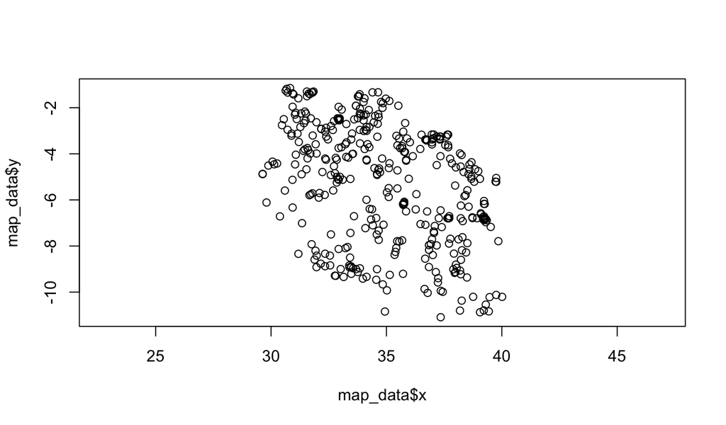

```r
plot(map_data$y ~ map_data$x, asp = 1)
```

A simple verion using `ggplot()` with points coloured by human population density

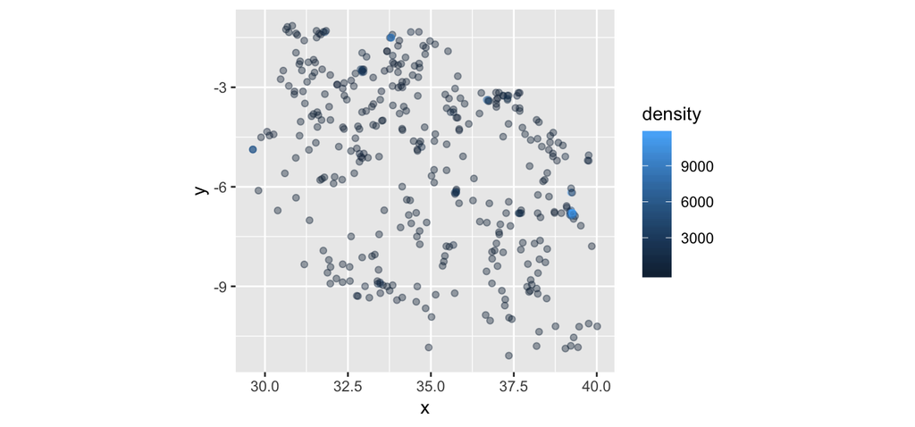

```r
ggplot(data = map_data, aes(x = x, y = y, col = density)) +
  geom_point(alpha = 0.4) + # makes points transparent
  coord_equal() # sets aspect ratio 1:1
```

## **ggmap** and `qmplot()`

Using `I()` prevents the plotting of a legend beside the map

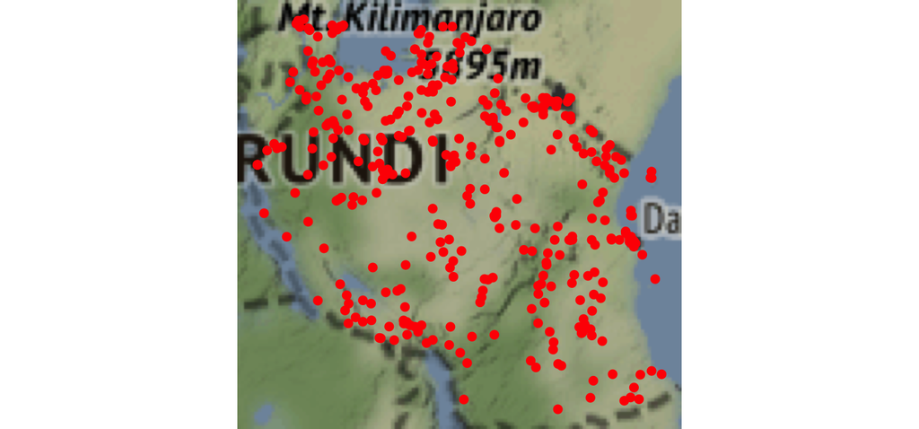

```r
qmplot(data = map_data, x = x, y = y, colour = I("red"),
       size = I(2), darken = .2, zoom = 4)
```